# Assignment week 11

Adrian Molière

2023-05-19

```r
suppressPackageStartupMessages({
  library(GenomicRanges)
  library(epiwraps)
  library(ggplot2)
  library(rGREAT)
  library(AnnotationHub)
  library(ensembldb)
  library(bsseq)
  library(BiocParallel)
  library(edgeR)
  library(DMRcate)
  library(rtracklayer)
  library(sechm)
  library(pheatmap)
  library(viridis)
  library(data.table)
})
set.seed(40)
```

## Load the data

Download:

```r
options(timeout = 6000)
download.file("https://ethz-ins.org/content/w11_practical.zip", "w11_practical.zip")
unzip("w11_practical.zip")
```

The .bigwig files have already been reduced to chromosome one and only have to be loaded here:

```r
tracksGr <- list("ATAC"="ATAC.rds",
                 "CTCF"="CTCF.rds",
                 "H3K27ac"="H3K27ac.rds",
                 "H3K4me3"="H3K4me3.rds",
                 "DNAme"="DNAm.rds")
tracksGr <- lapply(tracksGr, readRDS)
```

## Load the Annotation data

```r
ah <- AnnotationHub(localHub=TRUE)
```

```
## Using 'localHub=TRUE'
##   If offline, please also see BiocManager vignette section on offline use
```

## Load the bs-seq data

```r
bs <- readRDS("bs.rds") #
rowRanges(bs)
```

```
## GRanges object with 578097 ranges and 0 metadata columns:
##            seqnames    ranges strand
##               <Rle> <IRanges>  <Rle>
##        [1]    chr22  16050097      *
##        [2]    chr22  16050114      *
##        [3]    chr22  16050174      *
##        [4]    chr22  16050206      *
##        [5]    chr22  16050213      *
##        ...      ...       ...    ...
##   [578093]    chr22  51244314      *
##   [578094]    chr22  51244503      *
##   [578095]    chr22  51244509      *
##   [578096]    chr22  51244532      *
##   [578097]    chr22  51244561      *
##   -------
##   seqinfo: 2 sequences from an unspecified genome; no seqlengths
```

```r
pData(bs)
```

```
## DataFrame with 6 rows and 2 columns
##           Type        Pair
##    <character> <character>
## C1      cancer       pair1
## C2      cancer       pair2
## C3      cancer       pair3
## N1      normal       pair1
## N2      normal       pair2
## N3      normal       pair3
```

```r
bsseq::getMeth(bs, what = "perBase") #Matrix with CP fractions of all the elements
```

```
## <578097 x 6> DelayedMatrix object of type "double":
##                     C1           C2           C3           N1           N2
##      [1,]    0.3611976    0.5880200    0.6494494    0.7569841    0.6522832
##      [2,]    0.3615618    0.5880873    0.6491560    0.7570216    0.6521675
##      [3,]    0.3628482    0.5883253    0.6481194    0.7571542    0.6517589
##      [4,]    0.3635350    0.5884527    0.6475666    0.7572248    0.6515408
##      [5,]    0.3636854    0.5884806    0.6474458    0.7572403    0.6514931
##       ...            .            .            .            .            .
## [578093,] 0.0003250798 0.1434345143 0.6395898803 0.9853229735 0.9705508490
## [578094,] 0.0002370842 0.1330964304 0.6428852504 0.9843063765 0.9726137878
## [578095,] 0.0002347202 0.1327767257 0.6429949172 0.9842724484 0.9726769240
## [578096,] 0.0002258744 0.1315560318 0.6434181919 0.9841414069 0.9729176380
## [578097,] 0.0002151945 0.1300293137 0.6439545916 0.9839743312 0.9732182099
##                     N3
##      [1,]    0.6546393
##      [2,]    0.6544919
##      [3,]    0.6539729
##      [4,]    0.6536972
##      [5,]    0.6536370
##       ...            .
## [578093,] 0.9168743244
## [578094,] 0.9221953793
## [578095,] 0.9223590860
## [578096,] 0.9229837097
## [578097,] 0.9237647130
```

## Get annotations

```r
# genes
ensdb <- ah[["AH109336"]]
```

```
## loading from cache
```

```r
chr22 <-  GRanges(seqnames=Rle(c("22")),
                  ranges = IRanges(1, end=195471971))
genesChr22 <- genes(ensdb, columns=c("gene_seq_start", "gene_seq_end", "gene_name"),
                    filter=GRangesFilter(chr22))
seqlevelsStyle(genesChr22) <- "UCSC"
```

## Get methylation of the genes

```r
metPr <- bsseq::getMeth(bs,
                        regions=genesChr22,
                        what="perRegion")
colnames(metPr) <- colnames(bs)
rownames(metPr) <- genesChr22$gene_name
metPr <- metPr[!is.na(rowSums(metPr)),]
```

## Calculate differential methylation

```r
design <- model.matrix(~Type+Pair, data=pData(bs)) # design matrix
design # AM: normal or cancer and indication to which pair sample belongs, samples are paired form each patient for cancer and healthy



# adapt for methylation data
methdesign <- modelMatrixMeth(design)

seqAnnot <- sequencing.annotate(bs, methdesign, all.cov=TRUE, coef="Typenormal")
dmrcateRes <- dmrcate(seqAnnot, C=2, min.cpgs = 10, pcutoff=0.01)

dmrRanges <- extractRanges(dmrcateRes, genome="hg38")
saveRDS(dmrRanges, "dmr.rds")
```

```r
dmrRanges <- readRDS("dmr.rds")
dmrRangesGenes <- dmrRanges[!is.na(dmrRanges$overlapping.genes)]
```

```r
# Get the genes within Differentially methylated regions
topIdx <- order(dmrRangesGenes$min_smoothed_fdr)[1:5]
dmrRangesGenes[topIdx[1:5],]
```

```
## GRanges object with 5 ranges and 8 metadata columns:
##       seqnames            ranges strand |   no.cpgs min_smoothed_fdr  Stouffer
##          <Rle>         <IRanges>  <Rle> | <integer>        <numeric> <numeric>
##   [1]    chr22 19509895-19516468      * |       227     1.75373e-119  0.999844
##   [2]    chr22 46260498-46266828      * |       224     8.36602e-119  1.000000
##   [3]    chr22 46335852-46371682      * |       895     1.81094e-113  1.000000
##   [4]    chr22 44222390-44260925      * |       735      7.47512e-68  1.000000
##   [5]    chr22 45556799-45559373      * |        42      6.25889e-66  0.975632
##           HMFDR    Fisher   maxdiff  meandiff   overlapping.genes
##       <numeric> <numeric> <numeric> <numeric>         <character>
##   [1]  0.476167  1.000000  -5.04935 -1.050692               CDC45
##   [2]  0.508648  1.000000  -5.05652 -0.845169              PKDREJ
##   [3]  0.521215  1.000000  -5.43655  0.756617        TRMU, CELSR1
##   [4]  0.510145  1.000000   5.33654  1.106862 AL031595.2, SHISAL1
##   [5]  0.441571  0.986784   5.25405  1.806982               FBLN1
##   -------
##   seqinfo: 1 sequence from an unspecified genome; no seqlengths
```

```r
genesDmr <- unlist(tstrsplit(dmrRangesGenes[topIdx]$overlapping.genes, split=", "))
genesDmr <- genesDmr[!is.na(genesDmr)]
dmrGenes <- genesChr22[genesChr22$gene_name %in% genesDmr]
dmrGenes
```

```
## GRanges object with 6 ranges and 2 metadata columns:
##                   seqnames            ranges strand |   gene_name
##                      <Rle>         <IRanges>  <Rle> | <character>
##   ENSG00000093009    chr22 19479457-19520612      + |       CDC45
##   ENSG00000138944    chr22 44243665-44312951      - |     SHISAL1
##   ENSG00000077942    chr22 45502238-45601135      + |       FBLN1
##   ENSG00000130943    chr22 46255663-46263343      - |      PKDREJ
##   ENSG00000100416    chr22 46330875-46357340      + |        TRMU
##   ENSG00000075275    chr22 46360834-46537620      - |      CELSR1
##                           gene_id
##                       <character>
##   ENSG00000093009 ENSG00000093009
##   ENSG00000138944 ENSG00000138944
##   ENSG00000077942 ENSG00000077942
##   ENSG00000130943 ENSG00000130943
##   ENSG00000100416 ENSG00000100416
##   ENSG00000075275 ENSG00000075275
##   -------
##   seqinfo: 1 sequence from hg38 genome
```

## Plot methylation of genes of top DMRs

```r
metPr_top_dmrGenes <- metPr[dmrGenes$gene_name, ]
```

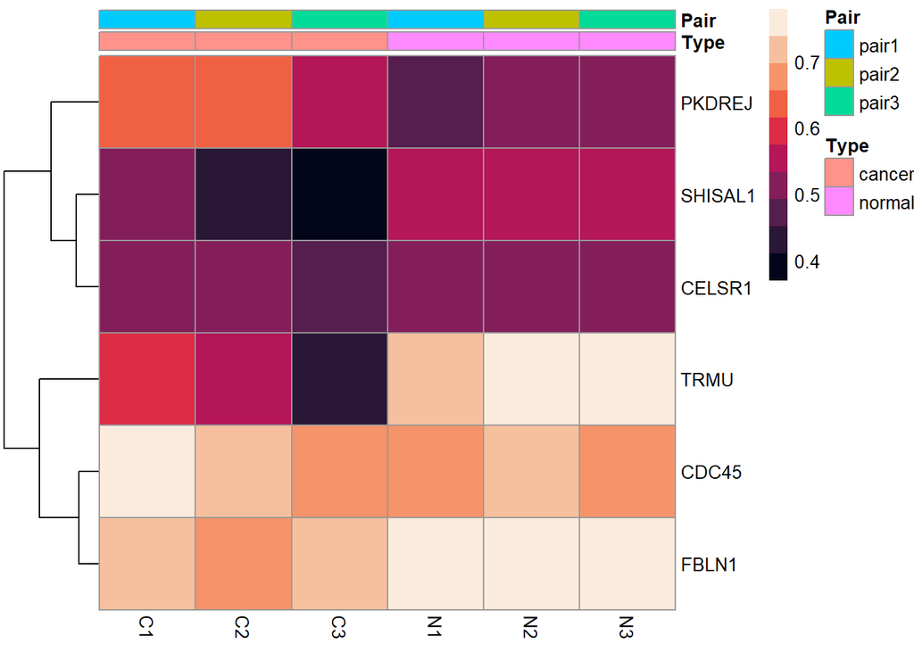

```r
library(viridis)
library(pheatmap)
annotationCol <- as.data.frame(pData(bs)[,c("Type","Pair")])
rownames(annotationCol) <- colnames(metPr_top_dmrGenes)
pheatmap::pheatmap(metPr_top_dmrGenes,
                   cluster_rows=TRUE,
                   cluster_cols=FALSE,
                   annotation_col=annotationCol,
                   show_rownames = TRUE,
                   color=rocket(10))
```

## Enrichment

```r
# Get all the genes in DMRs
All_Idx <- order(dmrRangesGenes$min_smoothed_fdr)
genesDmr_all <- unlist(tstrsplit(dmrRangesGenes[All_Idx]$overlapping.genes, split=", "))
genesDmr_all <- genesDmr_all[!is.na(genesDmr_all)]
dmrGenes_all <- genesChr22[genesChr22$gene_name %in% genesDmr_all]
dmrGenes_all
```

```
## GRanges object with 532 ranges and 2 metadata columns:
##                   seqnames            ranges strand |   gene_name
##                      <Rle>         <IRanges>  <Rle> | <character>
##   ENSG00000237438    chr22 17044873-17047426      + |       CECR7
##   ENSG00000177663    chr22 17084954-17115693      + |      IL17RA
##           LRG_355    chr22 17084959-17115694      + |      IL17RA
##   ENSG00000093072    chr22 17178790-17258235      - |        ADA2
##          LRG_1217    chr22 17178790-17219435      - |        ADA2
##               ...      ...               ...    ... .         ...
##   ENSG00000212569    chr22 50669804-50669901      + |       Y_RNA
##   ENSG00000251322    chr22 50674415-50733212      + |      SHANK3
##   ENSG00000100312    chr22 50738196-50745339      + |         ACR
##   ENSG00000079974    chr22 50767501-50783667      - |      RABL2B
##   ENSG00000184319    chr22 50798655-50799123      + |   RPL23AP82
##                           gene_id
##                       <character>
##   ENSG00000237438 ENSG00000237438
##   ENSG00000177663 ENSG00000177663
##           LRG_355         LRG_355
##   ENSG00000093072 ENSG00000093072
##          LRG_1217        LRG_1217
##               ...             ...
##   ENSG00000212569 ENSG00000212569
##   ENSG00000251322 ENSG00000251322
##   ENSG00000100312 ENSG00000100312
##   ENSG00000079974 ENSG00000079974
##   ENSG00000184319 ENSG00000184319
##   -------
##   seqinfo: 1 sequence from hg38 genome
```

```r
suppressPackageStartupMessages({
  library(rGREAT)
})
```

```r
job <- submitGreatJob(gr=dmrGenes_all, bg=genesChr22, species="hg38")
res <- getEnrichmentTables(job)
```

[output not shown]

```r
names(res)
```

```
## [1] "GO Molecular Function" "GO Biological Process" "GO Cellular Component"
```

We use all the genes of chromosome 22 as the background, since we want to know if a certain function is enriched in the differentially methylated genes of chromosome 22 in cancer patients compared to the control. We only use genes from chromsome 22 and not the whole genome as the background since certain functions might be enriched in the whole chromosome compared to the whole genome.

```r
bp <- res$`GO Biological Process`
head(bp)
```

```
##           ID                             name Hyper_Total_Regions
## 1 GO:0065007            biological regulation                1116
## 2 GO:0065008 regulation of biological quality                 424
## 3 GO:0050789 regulation of biological process                1088
## 4 GO:0050794   regulation of cellular process                1077
## 5 GO:0010646 regulation of cell communication                 415
## 6 GO:0023051          regulation of signaling                 416
##   Hyper_Expected Hyper_Foreground_Region_Hits Hyper_Fold_Enrichment
## 1       400.6154                          446              1.113287
## 2       152.2051                          198              1.300876
## 3       390.5641                          432              1.106092
## 4       386.6154                          428              1.107043
## 5       148.9744                          188              1.261962
## 6       149.3333                          188              1.258929
##   Hyper_Region_Set_Coverage Hyper_Term_Region_Coverage
```

[output cut: 20 more lines]

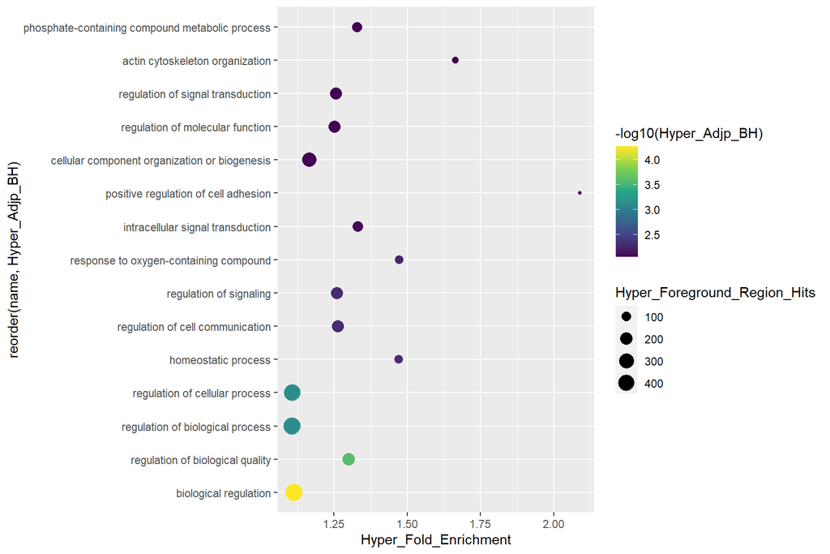

```r
ggplot(head(bp,15), aes(Hyper_Fold_Enrichment, reorder(name, Hyper_Adjp_BH), size=Hyper_Foreground_Region_Hits, color=-log10(Hyper_Adjp_BH))) + geom_point() + scale_color_viridis_c()
```

The biological processes are quite broad. However, there are a few interesting enrichments. Cancer cells undergo dramatic mechanobiological changes. This is potentially seen in the altered actin cytoskeleton organisation and the altered regulation of cell adhesion. Changes in cell adhesion could also be related to cancer metastasis. Altered response to oxygen-containing compounds is also interesting, since cancer cells are adapted to hypoxia.

```r
cc <- res$`GO Cellular Component`
head(cc)
```

```
##           ID                         name Hyper_Total_Regions Hyper_Expected
## 1 GO:0043226                    organelle                1238       444.4103
## 2 GO:0043229      intracellular organelle                1113       399.5385
## 3 GO:0031090           organelle membrane                 375       134.6154
## 4 GO:0044422               organelle part                 806       289.3333
## 5 GO:0043227   membrane-bounded organelle                1188       426.4615
## 6 GO:0044446 intracellular organelle part                 801       287.5385
##   Hyper_Foreground_Region_Hits Hyper_Fold_Enrichment Hyper_Region_Set_Coverage
## 1                          480              1.080083                 0.9022556
## 2                          439              1.098768                 0.8251880
## 3                          172              1.277714                 0.3233083
## 4                          328              1.133641                 0.6165414
## 5                          457              1.071609                 0.8590226
## 6                          326              1.133761                 0.6127820
##   Hyper_Term_Region_Coverage Hyper_Foreground_Gene_Hits
```

[output cut: 20 more lines]

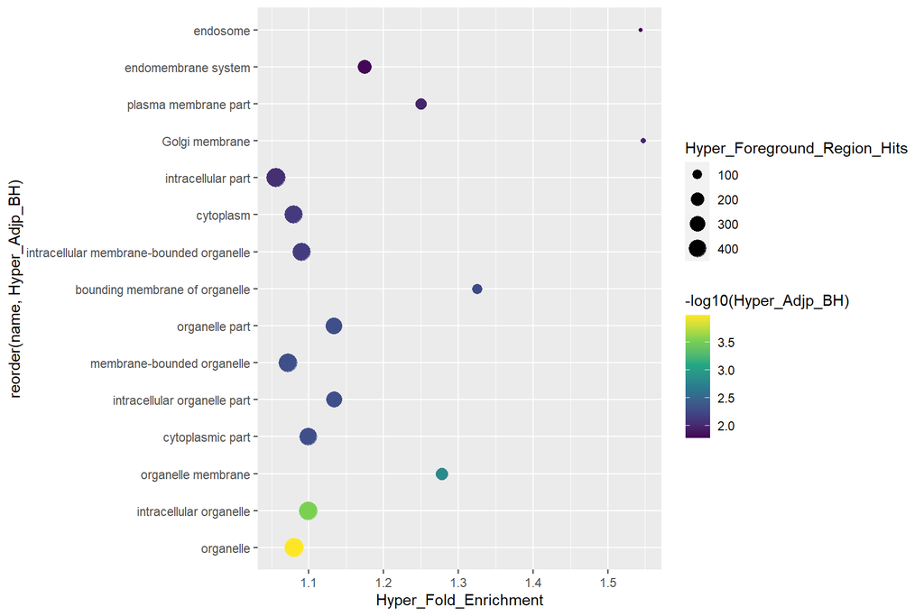

```r
ggplot(head(cc,15), aes(Hyper_Fold_Enrichment, reorder(name, Hyper_Adjp_BH), size=Hyper_Foreground_Region_Hits, color=-log10(Hyper_Adjp_BH))) + geom_point() + scale_color_viridis_c()
```

The cellular compartment analysis is too broad to make any conclusions. The strong enrichment of endosome and golgi membrane related genes could suggest altered intracellular transport in cancer cells.

```r
mf <- res$`GO Molecular Function`
head(mf)
```

```
##           ID                                                            name
## 1 GO:0003824                                              catalytic activity
## 2 GO:0004713                                protein tyrosine kinase activity
## 3 GO:0016740                                            transferase activity
## 4 GO:0016772 transferase activity, transferring phosphorus-containing groups
## 5 GO:0016301                                                 kinase activity
## 6 GO:0016773          phosphotransferase activity, alcohol group as acceptor
##   Hyper_Total_Regions Hyper_Expected Hyper_Foreground_Region_Hits
## 1                 705      253.07690                          298
## 2                  39       14.00000                           29
## 3                 276       99.07692                          132
## 4                 114       40.92308                           63
## 5                 108       38.76923                           60
## 6                 107       38.41026                           59
##   Hyper_Fold_Enrichment Hyper_Region_Set_Coverage Hyper_Term_Region_Coverage
```

[output cut: 20 more lines]

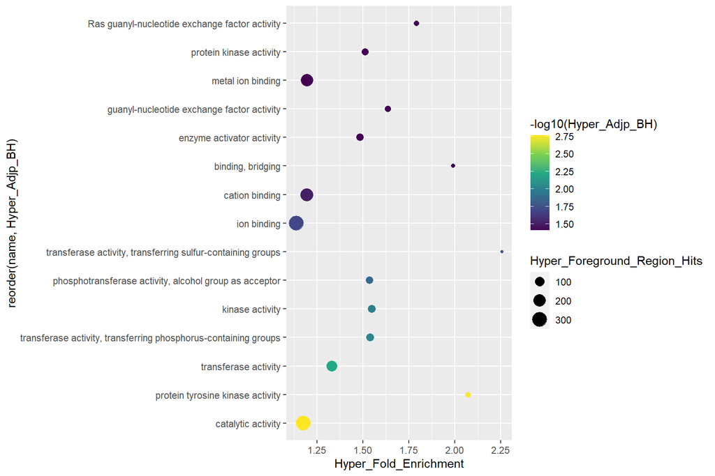

```r
ggplot(head(mf,15), aes(Hyper_Fold_Enrichment, reorder(name, Hyper_Adjp_BH), size=Hyper_Foreground_Region_Hits, color=-log10(Hyper_Adjp_BH))) + geom_point() + scale_color_viridis_c()
```